# EasyVisa Project - Ensemble Techniques

### Index

- Problem Statement
- Explore the dataset, Data Preprocessing and extract insights using Exploratory Data Analysis
- Questions on Exploratory Data Analysis(EDA)
- Building Bagging models (with hyperparameter tuning)
- Building Boosting models (with hyperparameter tuning)
- Bagging and Boosting models - Performance Summary - Train and Test
- Actionable Insights and Recommendations

## **1. Problem Statement**

#### Context:

Business communities in the United States are facing high demand for human resources, but one of the constant challenges is identifying and attracting the right talent, which is perhaps the most important element in remaining competitive. Companies in the United States look for hard-working, talented, and qualified individuals both locally as well as abroad.

The Immigration and Nationality Act (INA) of the US permits foreign workers to come to the United States to work on either a temporary or permanent basis. The act also protects US workers against adverse impacts on their wages or working conditions by ensuring US employers' compliance with statutory requirements when they hire foreign workers to fill workforce shortages. The immigration programs are administered by the Office of Foreign Labor Certification (OFLC).

OFLC processes job certification applications for employers seeking to bring foreign workers into the United States and grants certifications in those cases where employers can demonstrate that there are not sufficient US workers available to perform the work at wages that meet or exceed the wage paid for the occupation in the area of intended employment.

#### Objective:

In FY 2016, the OFLC processed 775,979 employer applications for 1,699,957 positions for temporary and permanent labor certifications. This was a nine percent increase in the overall number of processed applications from the previous year. The process of reviewing every case is becoming a tedious task as the number of applicants is increasing every year.

The increasing number of applicants every year calls for a Machine Learning based solution that can help in shortlisting the candidates having higher chances of VISA approval. OFLC has hired your firm EasyVisa for data-driven solutions. You as a data scientist have to analyze the data provided and, with the help of a classification model:

- Facilitate the process of visa approvals.
- Recommend a suitable profile for the applicants for whom the visa should be certified or denied based on the drivers that significantly influence the case status.

#### Data Description

The data contains the different attributes of the employee and the employer. The detailed data dictionary is given below.

- case_id: ID of each visa application
- continent: Information of continent the employee
- education_of_employee: Information of education of the employee
- has_job_experience: Does the employee has any job experience? Y= Yes; N = No
- requires_job_training: Does the employee require any job training? Y = Yes; N = No
- no_of_employees: Number of employees in the employer's company
- yr_of_estab: Year in which the employer's company was established
- region_of_employment: Information of foreign worker's intended region of employment in the US.
- prevailing_wage: Average wage paid to similarly employed workers in a specific occupation in the area of intended employment. The purpose of the prevailing wage is to ensure that the foreign worker is not underpaid compared to other workers offering the same or similar service in the same area of employment.
- unit_of_wage: Unit of prevailing wage. Values include Hourly, Weekly, Monthly, and Yearly.
- full_time_position: Is the position of work full-time? Y = Full Time Position; N = Part Time Position
- case_status: Flag indicating if the Visa was certified or denied

### Importing the required libraries

```python
# Ignore warnings
import warnings as wns
wns.filterwarnings('ignore')
```

```python
# import the important packages
# library used for data manipulation and analysis
import pandas as pd
# library used for working with arrays.
import numpy as np
# library for plots and visualisations
import matplotlib.pyplot as plt
import seaborn as sns
%matplotlib inline
```

```python
# Removing the limit of number of columns and rows printed
pd.set_option('display.max_columns',None) # Display all columns
pd.set_option('display.max_rows',200)# Display 200 rows.
```

## **2. Explore the Dataset, Data Preprocessing and extract insights using Exploratory Data Analysis.**

### Load the input file and understand the structure of the data

```python
#Parser engine to use. The C engine is faster while the python engine is currently more feature-complete.
url = "EasyVisa.csv"
Visa_df = pd.read_csv(url, engine="python")
```

```python
# Get the shape of the data.
print(f'The Easy Visa employer applications dataframe has {Visa_df.shape[0]} rows and {Visa_df.shape[1]} columns.')
```

```
The Easy Visa employer applications dataframe has 25480 rows and 12 columns.
```

```python
# Get a sample 10 rows of data using random state = 1
Visa_df.sample(n=10, random_state=1)
```

|  | case_id | continent | education_of_employee | has_job_experience | requires_job_training | no_of_employees | yr_of_estab | region_of_employment | prevailing_wage | unit_of_wage | full_time_position | case_status |
| --- | --- | --- | --- | --- | --- | --- | --- | --- | --- | --- | --- | --- |
| 17639 | EZYV17640 | Asia | Bachelor's | Y | N | 567 | 1992 | Midwest | 26842.9100 | Year | Y | Certified |
| 23951 | EZYV23952 | Oceania | Bachelor's | N | N | 619 | 1938 | Midwest | 66419.9800 | Year | Y | Certified |
| 8625 | EZYV8626 | Asia | Master's | N | N | 2635 | 2005 | South | 887.2921 | Hour | Y | Certified |
| 20206 | EZYV20207 | Asia | Bachelor's | Y | Y | 3184 | 1986 | Northeast | 49435.8000 | Year | Y | Certified |
| 7471 | EZYV7472 | Europe | Bachelor's | Y | N | 4681 | 1928 | West | 49865.1900 | Year | Y | Denied |
| 3433 | EZYV3434 | Asia | Bachelor's | Y | N | 222 | 1989 | South | 813.7261 | Hour | Y | Certified |
| 24440 | EZYV24441 | Europe | High School | N | Y | 3278 | 1994 | South | 204948.3900 | Year | Y | Denied |
| 12104 | EZYV12105 | Asia | Master's | Y | N | 1359 | 1997 | West | 202237.0400 | Year | N | Certified |
| 15656 | EZYV15657 | Asia | Bachelor's | N | N | 2081 | 2003 | West | 111713.0200 | Year | Y | Denied |
| 23110 | EZYV23111 | North America | Bachelor's | Y | N | 854 | 1998 | Northeast | 444.8257 | Hour | Y | Denied |

#### Observations:

- The EasyVisa DataFrame has 12 columns as mentioned in the Data Dictionary.
- Data in each row corresponds to the details of employer for each applicant's case status, both certified and denied.

```python
# use info() method to print a concise summary of the pandas DataFrame
Visa_df.info()
```

```
<class 'pandas.core.frame.DataFrame'>
RangeIndex: 25480 entries, 0 to 25479
Data columns (total 12 columns):
 #   Column                 Non-Null Count  Dtype
---  ------                 --------------  -----
 0   case_id                25480 non-null  object
 1   continent              25480 non-null  object
 2   education_of_employee  25480 non-null  object
 3   has_job_experience     25480 non-null  object
 4   requires_job_training  25480 non-null  object
 5   no_of_employees        25480 non-null  int64
 6   yr_of_estab            25480 non-null  int64
 7   region_of_employment   25480 non-null  object
 8   prevailing_wage        25480 non-null  float64
 9   unit_of_wage           25480 non-null  object
 10  full_time_position     25480 non-null  object
 11  case_status            25480 non-null  object
dtypes: float64(1), int64(2), object(9)
memory usage: 2.3+ MB
```

#### Observations:

- The EasyVisa DataFrame has 12 columns - 9 of them are objects, 3 are numeric.
- We can also notice that none of the columns have missing values.

### Fixing the data types

Converting "objects" to "category" reduces the data space required to store the dataframe.

```python
# Get the list of object columns.
object_cols = Visa_df.select_dtypes(['object']).columns
object_cols
```

```
Index(['case_id', 'continent', 'education_of_employee', 'has_job_experience',
       'requires_job_training', 'region_of_employment', 'unit_of_wage',
       'full_time_position', 'case_status'],
      dtype='object')
```

```python
# Converting each of the object columns to category.
for col in object_cols:
    Visa_df[col] = Visa_df[col].astype('category')
```

```python
# use info() method to print a concise summary of the pandas DataFrame
Visa_df.info()
```

```
<class 'pandas.core.frame.DataFrame'>
RangeIndex: 25480 entries, 0 to 25479
Data columns (total 12 columns):
 #   Column                 Non-Null Count  Dtype
---  ------                 --------------  -----
 0   case_id                25480 non-null  category
 1   continent              25480 non-null  category
 2   education_of_employee  25480 non-null  category
 3   has_job_experience     25480 non-null  category
 4   requires_job_training  25480 non-null  category
 5   no_of_employees        25480 non-null  int64
 6   yr_of_estab            25480 non-null  int64
 7   region_of_employment   25480 non-null  category
 8   prevailing_wage        25480 non-null  float64
 9   unit_of_wage           25480 non-null  category
 10  full_time_position     25480 non-null  category
 11  case_status            25480 non-null  category
dtypes: category(9), float64(1), int64(2)
memory usage: 2.3 MB
```

#### Observations:

- The EasyVisa DataFrame is modified to update the object data type to category.

### Summary of the dataset

```python
# using the describe() menthod to get the 5 point summary of the numerical columns in the dataframe.
# .T will transponse the table into a readable format with dataframe columns arranged in rows.
Visa_df.describe().T
```

|  | count | mean | std | min | 25% | 50% | 75% | max |
| --- | --- | --- | --- | --- | --- | --- | --- | --- |
| no_of_employees | 25480.0 | 5667.043210 | 22877.928848 | -26.0000 | 1022.00 | 2109.00 | 3504.0000 | 602069.00 |
| yr_of_estab | 25480.0 | 1979.409929 | 42.366929 | 1800.0000 | 1976.00 | 1997.00 | 2005.0000 | 2016.00 |
| prevailing_wage | 25480.0 | 74455.814592 | 52815.942327 | 2.1367 | 34015.48 | 70308.21 | 107735.5125 | 319210.27 |

#### Observations:

This is the 5 point summary of 3 numerical columns.

```python
# using the describe() menthod to get the 5 point summary
# using 'include' to inculde "object" and "category" columns in the dataframe.
# .T will transponse the table into a readable format with dataframe columns arranged in rows.
Visa_df.describe(include='category').T
```

|  | count | unique | top | freq |
| --- | --- | --- | --- | --- |
| case_id | 25480 | 25480 | EZYV9999 | 1 |
| continent | 25480 | 6 | Asia | 16861 |
| education_of_employee | 25480 | 4 | Bachelor's | 10234 |
| has_job_experience | 25480 | 2 | Y | 14802 |
| requires_job_training | 25480 | 2 | N | 22525 |
| region_of_employment | 25480 | 5 | Northeast | 7195 |
| unit_of_wage | 25480 | 4 | Year | 22962 |
| full_time_position | 25480 | 2 | Y | 22773 |
| case_status | 25480 | 2 | Certified | 17018 |

#### Observations:

- For the column 'case_id', it is the unique for all rows and is not significant for further analysis.
- For the column 'continent', it has 6 unique values - The most frequent one is 'Asia', with a frequency of 16861.
- For the column 'education_of_employee', it has 4 unique values - The most frequent one is 'Bachelor's', with a frequency of 10234.
- For the column 'has_job_experience', it has 2 unique values 'Y' and 'N'. The most frequent one is 'Y', with a frequency of 14802.
- For the column 'requires_job_training', it has two unique values - 'Y' and 'N'. 'N' appears more than 'Y'.
- For the column 'region_of_employment', it has 5 unique values - The most frequent one is 'Northeast', with a frequency of 7195.
- For the column 'unit_of_wage', it has 4 unique values - The most frequent one is 'Year', with a frequency of 22962.
- For the column 'full_time_position', it has two unique values - 'Y' and 'N'. 'Y' appears more than 'N'.
- For the column 'case_status', it has 2 unique values 'Certified' and 'Denied'. The most frequent one is 'Certified', with a frequency of 17018.

```python
# let's create a copy of the data to avoid any changes to original data
Visa_Data = Visa_df.copy()
```

### Data Preprocessing

```python
# 'case_id' is unique for all rows and is not significant for further analysis.
Visa_Data.drop(columns="case_id",axis=1,inplace=True)
```

```python
# hand-picking the list of numerical columns in the dataset.
numeric_cols = ['no_of_employees','yr_of_estab','prevailing_wage']
```

```python
# Get the list of category columns in the dataset.
category_cols = []
# for look to find the columns that are not numerical
for col in Visa_Data.columns.to_list():
    if col not in numeric_cols:
        category_cols.append(col)
category_cols
```

```
['continent',
 'education_of_employee',
 'has_job_experience',
 'requires_job_training',
 'region_of_employment',
 'unit_of_wage',
 'full_time_position',
 'case_status']
```

### Missing Value Treatment

```python
# checking for missing value
Visa_Data.isnull().sum()
```

```
continent                0
education_of_employee    0
has_job_experience       0
requires_job_training    0
no_of_employees          0
yr_of_estab              0
region_of_employment     0
prevailing_wage          0
unit_of_wage             0
full_time_position       0
case_status              0
dtype: int64
```

#### Observations:

There are no missing values in the dataset. But that does not mean there are invalid (or unexpected) values.

Lets look at the category columns to see if all the values are expected.

```python
# Get the value counts for category columns.
for col in category_cols:
    print(Visa_Data[col].value_counts())
    print("-" * 40)
```

```
Asia             16861
Europe            3732
North America     3292
South America      852
Africa             551
Oceania            192
Name: continent, dtype: int64
----------------------------------------
Bachelor's     10234
Master's        9634
High School     3420
Doctorate       2192
Name: education_of_employee, dtype: int64
----------------------------------------
Y    14802
N    10678
Name: has_job_experience, dtype: int64
----------------------------------------
N    22525
Y     2955
Name: requires_job_training, dtype: int64
----------------------------------------
Northeast    7195
South        7017
West         6586
Midwest      4307
Island        375
Name: region_of_employment, dtype: int64
----------------------------------------
Year     22962
Hour      2157
Week       272
Month       89
Name: unit_of_wage, dtype: int64
----------------------------------------
Y    22773
N     2707
Name: full_time_position, dtype: int64
----------------------------------------
Certified    17018
Denied        8462
Name: case_status, dtype: int64
----------------------------------------
```

#### Observations:

The value counts for the categorical columns looks good.

Let's add a numeric column with case_status 'Certified' as 0 and 'Denied' as 1.

```python
# Rename the column booking_status as booking_status_desc.
Visa_Data.rename(columns={'case_status':'case_status_desc'},inplace=True)
# Apply the function to update case_status 'Certified' as 0 and 'Denied' as 1.
Visa_Data['case_status'] = Visa_Data['case_status_desc'].apply(lambda x:0 if x == "Certified" else 1)
# Convert case_status column to integer.
Visa_Data['case_status'] = Visa_Data['case_status'].astype('int64')
```

```python
# Get a sample 10 rows of data using random state = 1
Visa_Data.sample(n=10, random_state=1)
```

|  | continent | education_of_employee | has_job_experience | requires_job_training | no_of_employees | yr_of_estab | region_of_employment | prevailing_wage | unit_of_wage | full_time_position | case_status_desc | case_status |
| --- | --- | --- | --- | --- | --- | --- | --- | --- | --- | --- | --- | --- |
| 17639 | Asia | Bachelor's | Y | N | 567 | 1992 | Midwest | 26842.9100 | Year | Y | Certified | 0 |
| 23951 | Oceania | Bachelor's | N | N | 619 | 1938 | Midwest | 66419.9800 | Year | Y | Certified | 0 |
| 8625 | Asia | Master's | N | N | 2635 | 2005 | South | 887.2921 | Hour | Y | Certified | 0 |
| 20206 | Asia | Bachelor's | Y | Y | 3184 | 1986 | Northeast | 49435.8000 | Year | Y | Certified | 0 |
| 7471 | Europe | Bachelor's | Y | N | 4681 | 1928 | West | 49865.1900 | Year | Y | Denied | 1 |
| 3433 | Asia | Bachelor's | Y | N | 222 | 1989 | South | 813.7261 | Hour | Y | Certified | 0 |
| 24440 | Europe | High School | N | Y | 3278 | 1994 | South | 204948.3900 | Year | Y | Denied | 1 |
| 12104 | Asia | Master's | Y | N | 1359 | 1997 | West | 202237.0400 | Year | N | Certified | 0 |
| 15656 | Asia | Bachelor's | N | N | 2081 | 2003 | West | 111713.0200 | Year | Y | Denied | 1 |
| 23110 | North America | Bachelor's | Y | N | 854 | 1998 | Northeast | 444.8257 | Hour | Y | Denied | 1 |

```python
# use info() method to print a concise summary of the pandas DataFrame
Visa_Data.info()
```

```
<class 'pandas.core.frame.DataFrame'>
RangeIndex: 25480 entries, 0 to 25479
Data columns (total 12 columns):
 #   Column                 Non-Null Count  Dtype
---  ------                 --------------  -----
 0   continent              25480 non-null  category
 1   education_of_employee  25480 non-null  category
 2   has_job_experience     25480 non-null  category
 3   requires_job_training  25480 non-null  category
 4   no_of_employees        25480 non-null  int64
 5   yr_of_estab            25480 non-null  int64
 6   region_of_employment   25480 non-null  category
 7   prevailing_wage        25480 non-null  float64
 8   unit_of_wage           25480 non-null  category
 9   full_time_position     25480 non-null  category
 10  case_status_desc       25480 non-null  category
 11  case_status            25480 non-null  int64
dtypes: category(8), float64(1), int64(3)
memory usage: 996.6 KB
```

## Exploratory Data Analysis (EDA)

### Univariate Analysis

```python
# function to plot a boxplot and a histogram along the same scale.
def histogram_boxplot(data, feature, figsize=(12, 7), kde=False, bins=None):
    """
    Boxplot and histogram combined

    data: dataframe
    feature: dataframe column
    figsize: size of figure (default (12,7))
    kde: whether to the show density curve (default False)
    bins: number of bins for histogram (default None)
    """
    f2, (ax_box2, ax_hist2) = plt.subplots(
        nrows=2,  # Number of rows of the subplot grid= 2
        sharex=True,  # x-axis will be shared among all subplots
        gridspec_kw={"height_ratios": (0.25, 0.75)},
        figsize=figsize,
    )  # creating the 2 subplots
    sns.boxplot(
        data=data, x=feature, ax=ax_box2, showmeans=True, color="violet"
    )  # boxplot will be created and a star will indicate the mean value of the column
    sns.histplot(
        data=data, x=feature, kde=kde, ax=ax_hist2, bins=bins, palette="winter"
    ) if bins else sns.histplot(
        data=data, x=feature, kde=kde, ax=ax_hist2
    )  # For histogram
    ax_hist2.axvline(
        data[feature].mean(), color="green", linestyle="--"
    )  # Add mean to the histogram
    ax_hist2.axvline(
        data[feature].median(), color="black", linestyle="-"
    )  # Add median to the histogram
```

```python
# function to create labeled barplots

def labeled_barplot(data, feature, perc=False, n=None):
    """
    Barplot with percentage at the top

    data: dataframe
    feature: dataframe column
    perc: whether to display percentages instead of count (default is False)
    n: displays the top n category levels (default is None, i.e., display all levels)
    """

    total = len(data[feature])  # length of the column
    count = data[feature].nunique()
    if n is None:
        plt.figure(figsize=(count + 1, 5))
    else:
        plt.figure(figsize=(n + 1, 5))

    plt.xticks(rotation=60, fontsize=12)
    ax = sns.countplot(
        data=data,
        x=feature,
        palette="Paired",
        order=data[feature].value_counts().index[:n].sort_values(),
    )

    for p in ax.patches:
        if perc == True:
            label = "{:.2f}%".format(
                100 * p.get_height() / total
            )  # percentage of each class of the category
        else:
            label = p.get_height()  # count of each level of the category

        x = p.get_x() + p.get_width() / 2  # width of the plot
        y = p.get_height()  # height of the plot

        ax.annotate(
            label,
            (x, y),
            ha="center",
            va="center",
            size=12,
            xytext=(0, 5),
            textcoords="offset points",
        )  # annotate the percentage

    plt.show()  # show the plot
# for col in category_cols:
#     print("# Display a labeled_barplot for the category column '{0}'".format(col))
#     print("labeled_barplot(Visa_Data,'{0}',kde=True)".format(col))
#     print("-" * 40)
```

#### Starting with the dependent variable booking status

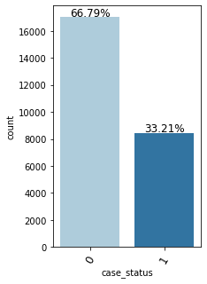

```python
# Display a labeled_barplot for the category column 'case_status'
labeled_barplot(Visa_Data,'case_status',perc=True)
```

#### Observations:

- The field booking_status has two unique values - 'Certified' and 'Denied'.
- There are 67% of observations with booking status = 'Certified' and 33% of observations with booking status = 'Denied'

#### Exploring the independent variables

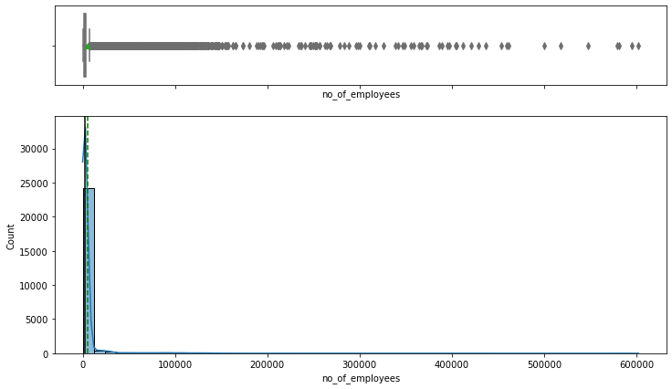

```python
# Display a histogram and boxplot with kde curve for the numeric column 'no_of_employees'
histogram_boxplot(Visa_Data,'no_of_employees',kde=True,bins=50)
```

#### Observations:

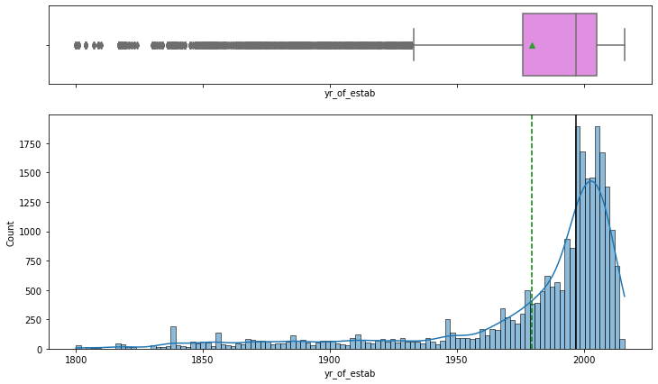

```python
# Display a histogram and boxplot with kde curve for the numeric column 'yr_of_estab'
histogram_boxplot(Visa_Data,'yr_of_estab',kde=True)
```

#### Observations:

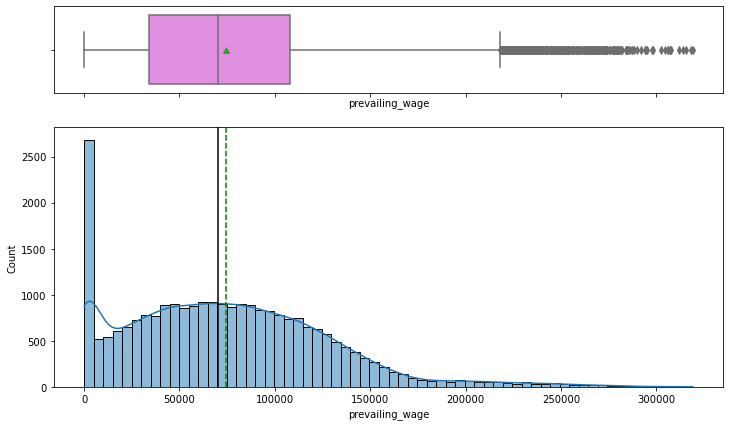

```python
# Display a histogram and boxplot with kde curve for the numeric column 'prevailing_wage'
histogram_boxplot(Visa_Data,'prevailing_wage',kde=True)
```

#### Observations:

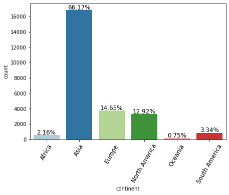

```python
# Display a labeled_barplot for the category column 'continent'
labeled_barplot(Visa_Data,'continent',perc=True)
```

#### Observations:

- The field continent signifies the 6 continents in earth.
- There are 66.17% of observations with continent Asia, followed by Europe with 14.65%

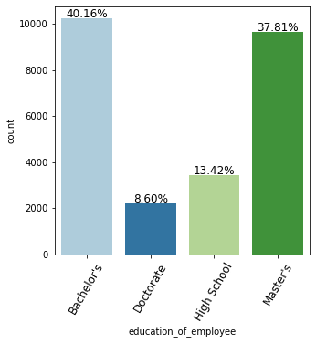

```python
# Display a labeled_barplot for the category column 'education_of_employee'
labeled_barplot(Visa_Data,'education_of_employee',perc=True)
```

#### Observations:

- The field education_of_employee signifies the 4 levels of education.
- There are 40.16% of observations with education_of_employee 'Bachelors', followed by 'Masters' with 37.81%

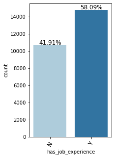

```python
# Display a labeled_barplot for the category column 'has_job_experience'
labeled_barplot(Visa_Data,'has_job_experience',perc=True)
```

#### Observations:

- The field has_job_experience has two unique values - 'N' and 'Y'. (No and Yes)
- There are 58% of observations with has_job_experience = 'Y' and 42% of observations with has_job_experience = 'N'

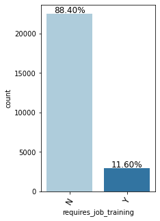

```python
# Display a labeled_barplot for the category column 'requires_job_training'
labeled_barplot(Visa_Data,'requires_job_training',perc=True)
```

#### Observations:

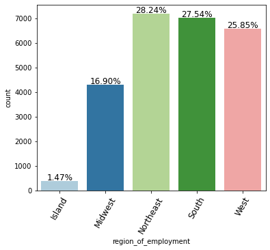

```python
# Display a labeled_barplot for the category column 'region_of_employment'
labeled_barplot(Visa_Data,'region_of_employment',perc=True)
```

#### Observations:

- The field 'region_of_employment' signifies the 5 regions in United States.
- There are 28.24% of observations with region_of_employment 'Northeast',closely followed by 'South' with 27.54%

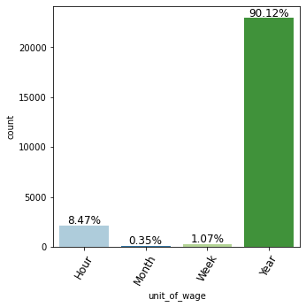

```python
# Display a labeled_barplot for the category column 'unit_of_wage'
labeled_barplot(Visa_Data,'unit_of_wage',perc=True)
```

#### Observations:

- The field 'unit_of_wage' signifies the 4 units of wage.
- There are 90.12% of observations with unit_of_wage 'Year', followed by 'Hour' with only 8.47%

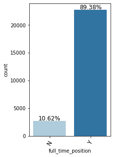

```python
# Display a labeled_barplot for the category column 'full_time_position'
labeled_barplot(Visa_Data,'full_time_position',perc=True)
```

#### Observations:

- The field full_time_position has two unique values - 'N' and 'Y'. (No and Yes)
- There are 89% of observations with full_time_position = 'Y' and 11% of observations with full_time_position = 'N'

### Bivariate and Multivariate Analysis

#### Sarting with pairplot and heat map of numerical fields

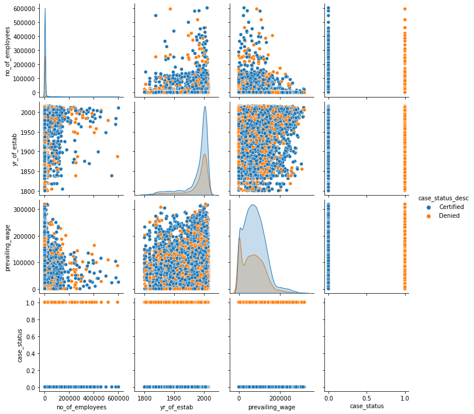

```python
# Display a pair plot to find the relationship between numerical fields.
sns.pairplot(Visa_Data,hue='case_status_desc')
plt.show()
```

#### Observations:

- There seems to have no correlation between the numerical fields.

```python
# Print the correlation between numerical columns.
Visa_Data.corr().round(3)
```

|  | no_of_employees | yr_of_estab | prevailing_wage | case_status |
| --- | --- | --- | --- | --- |
| no_of_employees | 1.000 | -0.018 | -0.010 | -0.009 |
| yr_of_estab | -0.018 | 1.000 | 0.012 | -0.009 |
| prevailing_wage | -0.010 | 0.012 | 1.000 | -0.076 |
| case_status | -0.009 | -0.009 | -0.076 | 1.000 |

#### Observations:

- There seems to be very low correlation between the numerical fields as seen in the above table.

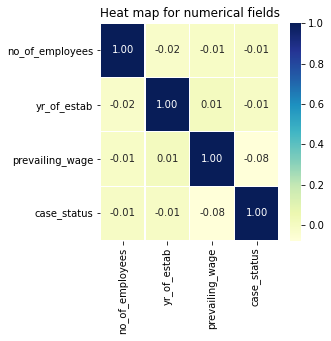

```python
# Set the figure size and title for the plot
plt.figure(figsize=(4,4))
plt.title('Heat map for numerical fields')

# Display a heat map to find the relationship between numerical fields.
sns.heatmap(Visa_Data.corr(),annot=True,linewidths=0.2,fmt=".2f",cmap="YlGnBu")
plt.show()
```

#### Observations (as per the heatmap):

- There seems to be very low correlation between the numerical fields as seen in the above heatmap.

### Bivariate analysis

```python
### function to plot distributions wrt target
def distribution_plot_wrt_target(data, predictor, target):

    fig, axs = plt.subplots(2, 2, figsize=(12, 10))

    target_uniq = data[target].unique()

    axs[0, 0].set_title("Distribution of target for target=" + str(target_uniq[0]))
    sns.histplot(
        data=data[data[target] == target_uniq[0]],
        x=predictor,
        kde=True,
        ax=axs[0, 0],
        color="teal",
        stat="density",
    )

    axs[0, 1].set_title("Distribution of target for target=" + str(target_uniq[1]))
    sns.histplot(
        data=data[data[target] == target_uniq[1]],
        x=predictor,
        kde=True,
        ax=axs[0, 1],
        color="orange",
        stat="density",
    )

    axs[1, 0].set_title("Boxplot w.r.t target")
    sns.boxplot(data=data, x=target, y=predictor, ax=axs[1, 0], palette="gist_rainbow")

    axs[1, 1].set_title("Boxplot (without outliers) w.r.t target")
    sns.boxplot(
        data=data,
        x=target,
        y=predictor,
        ax=axs[1, 1],
        showfliers=False,
        palette="gist_rainbow",
    )

    plt.tight_layout()
    plt.show()
```

```python
# function to plot stacked bar chart
def stacked_barplot(data, predictor, target):
    """
    Print the category counts and plot a stacked bar chart

    data: dataframe
    predictor: independent variable
    target: target variable
    """
    count = data[predictor].nunique()
    sorter = data[target].value_counts().index[-1]
    tab1 = pd.crosstab(data[predictor], data[target], margins=True).sort_values(
        by=sorter, ascending=False
    )
    print(tab1.head(10))
    print("-" * 120)
    tab = pd.crosstab(data[predictor], data[target], normalize="index").sort_values(
        by=sorter, ascending=False
    )
    tab = tab.head(10)
    if count > 10:
        count = 10
    tab.plot(kind="bar", stacked=True, figsize=(count + 5, 6))
    plt.xticks(rotation=60, fontsize=12)
    plt.legend(
        loc="lower left", frameon=False,
    )
    plt.legend(loc="upper left", bbox_to_anchor=(1, 1))
    plt.show()

# for col in category_cols:
#     if col != 'case_status':
#         print("# This is the stacked barplot for {} with target as Case status".format(col))
#         print("stacked_barplot(Visa_Data, '{}', 'case_status_desc')".format(col))
#         print("-" * 40)
```

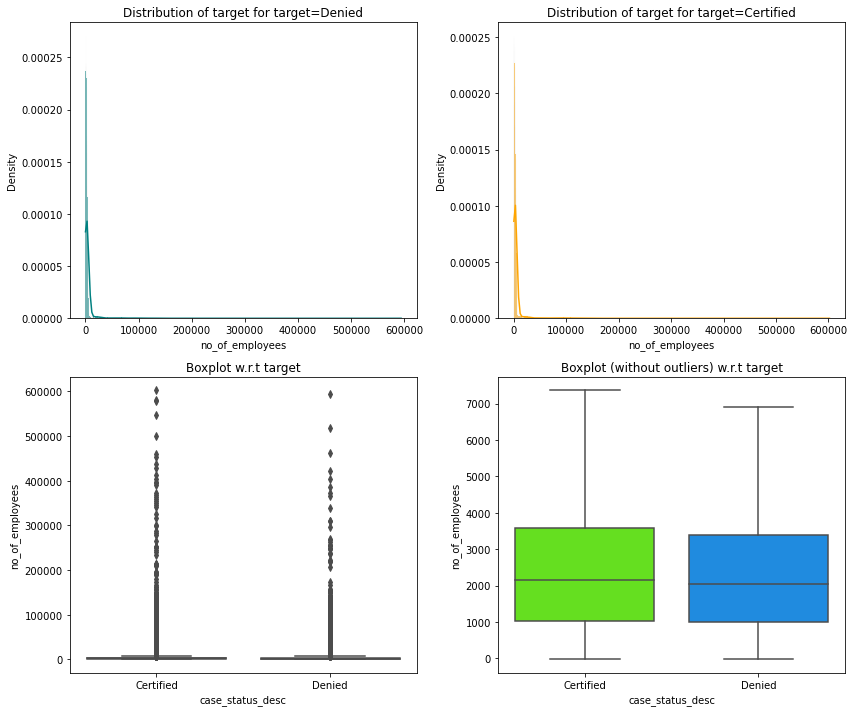

```python
# This is the distribution plot with respect to target for no_of_employees with target as Booking status
distribution_plot_wrt_target(Visa_Data, 'no_of_employees', 'case_status_desc')
```

#### Observations:

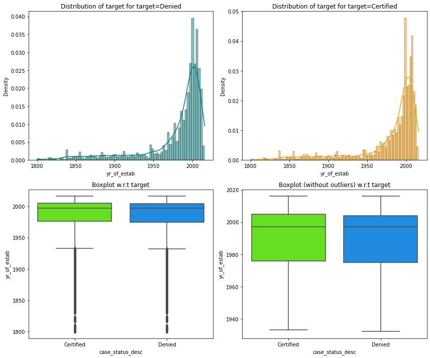

```python
# This is the distribution plot with respect to target for yr_of_estab with target as Booking status
distribution_plot_wrt_target(Visa_Data, 'yr_of_estab', 'case_status_desc')
```

#### Observations:

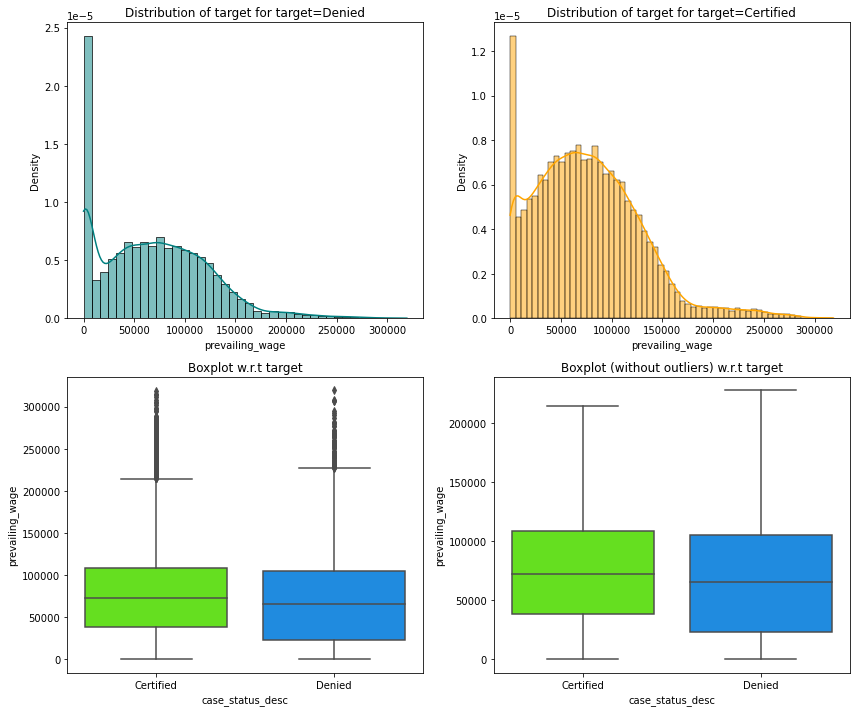

```python
# This is the distribution plot with respect to target for prevailing_wage with target as Case status
distribution_plot_wrt_target(Visa_Data, 'prevailing_wage', 'case_status_desc')
```

#### Observations:

- As observed in heatmap, the prevailing wage does not play a major factor in deciding the case status.
- Being said that, it can be observed that the median prevailing wage for a certified cases is greater than median prevailing wage for a denied cases.

```
case_status_desc  Certified  Denied    All
continent
All                   17018    8462  25480
Asia                  11012    5849  16861
North America          2037    1255   3292
Europe                 2957     775   3732
South America           493     359    852
Africa                  397     154    551
Oceania                 122      70    192
------------------------------------------------------------------------------------------------------------------------
```

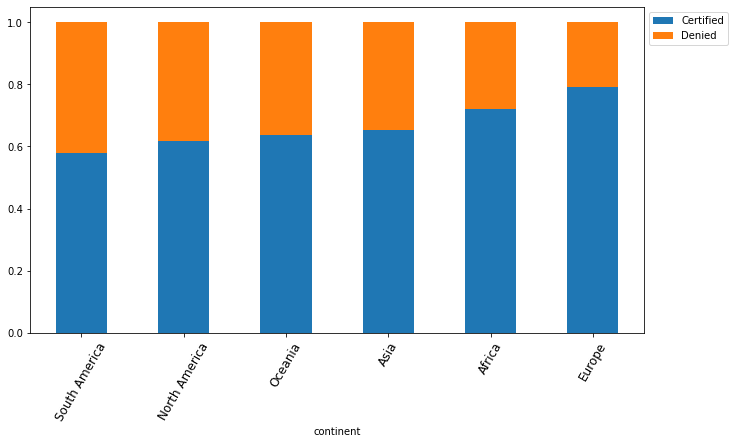

```python
# This is the stacked barplot for continent with target as Case status
stacked_barplot(Visa_Data, 'continent', 'case_status_desc')
```

#### Observations:

- The visa approval rates are not the same for all continents, but ranges from 60% to 80% approvals for all them.
- The approval rates are higher for Europe and lowest for South America, but the number of appications should also be taken into account.

```
case_status_desc       Certified  Denied    All
education_of_employee
All                        17018    8462  25480
Bachelor's                  6367    3867  10234
High School                 1164    2256   3420
Master's                    7575    2059   9634
Doctorate                   1912     280   2192
------------------------------------------------------------------------------------------------------------------------
```

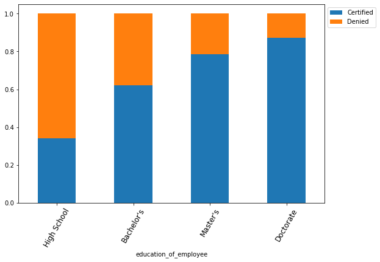

```python
# This is the stacked barplot for education_of_employee with target as Case status
stacked_barplot(Visa_Data, 'education_of_employee', 'case_status_desc')
```

#### Observations:

- The feature 'education_of_employee' does play a significant role in visa approvals.
- The approval rates are higher for employees with 'Doctorate' degree and lowest for 'High School', but the number of appications should also be taken into account.

```
case_status_desc    Certified  Denied    All
has_job_experience
All                     17018    8462  25480
N                        5994    4684  10678
Y                       11024    3778  14802
------------------------------------------------------------------------------------------------------------------------
```

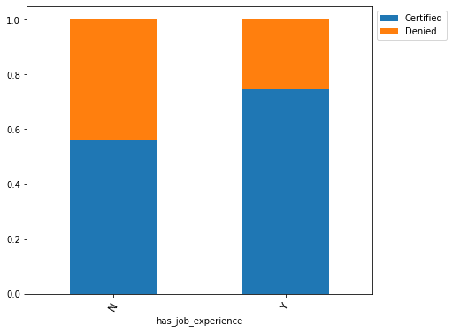

```python
# This is the stacked barplot for has_job_experience with target as Case status
stacked_barplot(Visa_Data, 'has_job_experience', 'case_status_desc')
```

#### Observations:

- The feature 'has_job_experience' does play a significant role in visa approvals.
- The approval rates are higher for employees with job experience.

```
case_status_desc       Certified  Denied    All
requires_job_training
All                        17018    8462  25480
N                          15012    7513  22525
Y                           2006     949   2955
------------------------------------------------------------------------------------------------------------------------
```

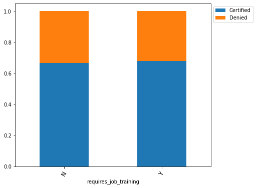

```python
# This is the stacked barplot for requires_job_training with target as Case status
stacked_barplot(Visa_Data, 'requires_job_training', 'case_status_desc')
```

#### Observations:

- The feature 'requires_job_training' does not play a significant role in visa approvals.
- The approval rates are almost the same for employees with and without job training.

```
case_status_desc      Certified  Denied    All
region_of_employment
All                       17018    8462  25480
Northeast                  4526    2669   7195
West                       4100    2486   6586
South                      4913    2104   7017
Midwest                    3253    1054   4307
Island                      226     149    375
------------------------------------------------------------------------------------------------------------------------
```

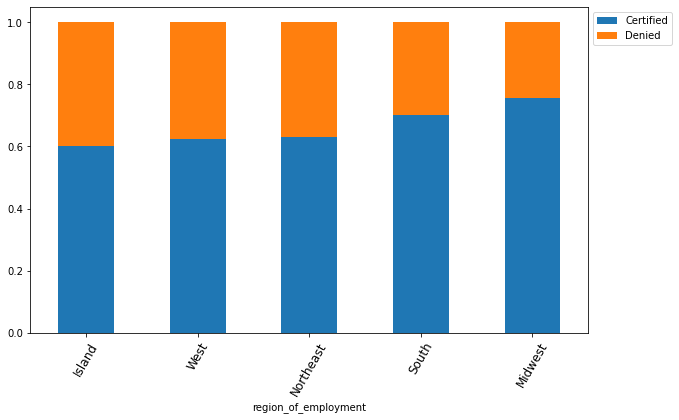

```python
# This is the stacked barplot for region_of_employment with target as Case status
stacked_barplot(Visa_Data, 'region_of_employment', 'case_status_desc')
```

#### Observations:

```
case_status_desc  Certified  Denied    All
unit_of_wage
All                   17018    8462  25480
Year                  16047    6915  22962
Hour                    747    1410   2157
Week                    169     103    272
Month                    55      34     89
------------------------------------------------------------------------------------------------------------------------
```

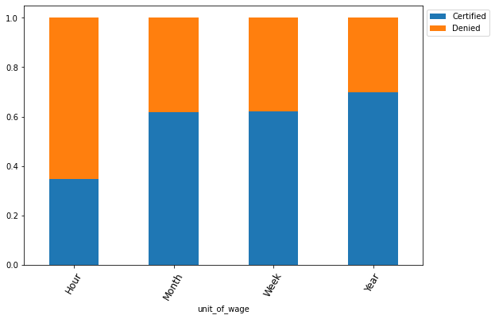

```python
# This is the stacked barplot for unit_of_wage with target as Case status
stacked_barplot(Visa_Data, 'unit_of_wage', 'case_status_desc')
```

#### Observations:

```
case_status_desc    Certified  Denied    All
full_time_position
All                     17018    8462  25480
Y                       15163    7610  22773
N                        1855     852   2707
------------------------------------------------------------------------------------------------------------------------
```

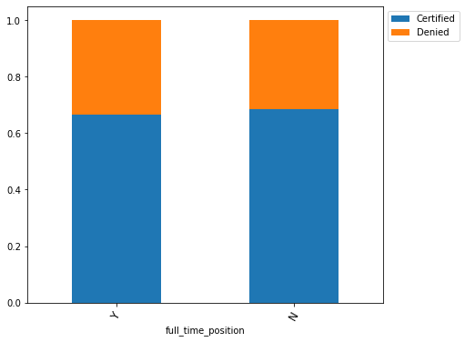

```python
# This is the stacked barplot for full_time_position with target as Case status
stacked_barplot(Visa_Data, 'full_time_position', 'case_status_desc')
```

#### Observations:

- The feature 'full_time_position' does not play a significant role in visa approvals.
- The approval rates are almost the same for employees with and without full time position.

### Multivariate analysis

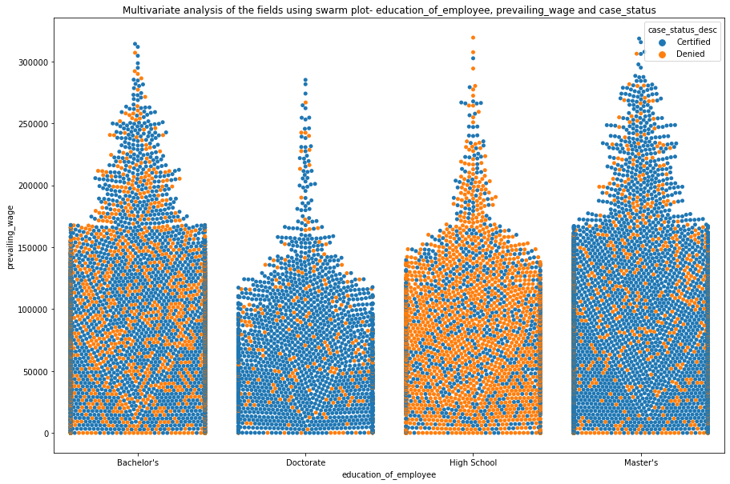

```python
# Set the figure size and title for the plot
plt.figure(figsize=(15, 10))
plt.title('Multivariate analysis of the fields using swarm plot- education_of_employee, prevailing_wage and case_status')

# Swarm plot for analying the fields - education_of_employee, prevailing_wage and case_status_desc.
sns.swarmplot(x="education_of_employee", y="prevailing_wage",hue="case_status_desc",data=Visa_Data)
plt.show()
```

#### Observations:

- The less number of visa denials with education_of_employee = 'Doctorate' is clearly evident from the swarm plot. Also the high number of denials with education_of_employee = 'High School' is evident too.
- The prevailing wage is not significantly changing for the level of education, the maxmium for each of these education levels is around 300K USD.
- It can also be obvserved that the number of positions with higher prevailing wage is available with education_of_employee = 'Masters'. We have to also consider the less data points for education_of_employee = 'Doctorate'.

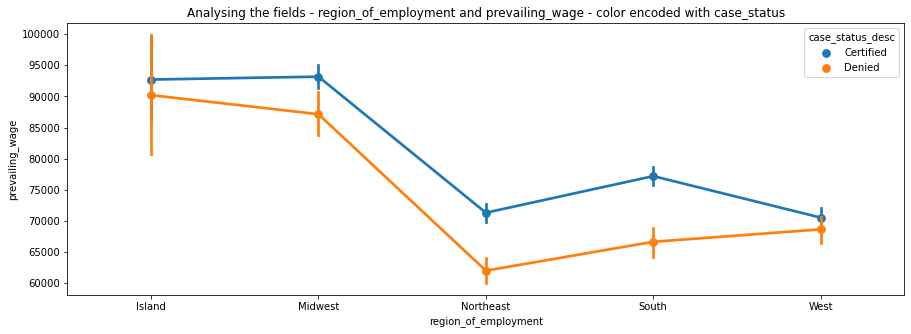

```python
# Set the figure size and title for the plot
plt.figure(figsize=(15,5))
plt.title('Analysing the fields - region_of_employment and prevailing_wage - color encoded with case_status')

# Show the pointplot with a legend - region_of_employment and prevailing_wage - color encoded with case_status
sns.pointplot(x="region_of_employment", y="prevailing_wage", hue = 'case_status_desc',  data=Visa_Data)
plt.show()
```

#### Observations:

- It is mentioned that the purpose of the prevailing wage is to ensure that the foreign worker is not underpaid compared to other workers offering the same or similar service in the same area of employment. It can be noticed that there is big difference in average prevailing wage for approved and denied cases in Northeast and South regions.
- In the West region, there is no significant difference in average prevailing wage for approved and denied cases.
- In the Island region, we can see the prevailing wage is high, but for denied cases, there seems to have a huge fluctuation in average prevailing wage.

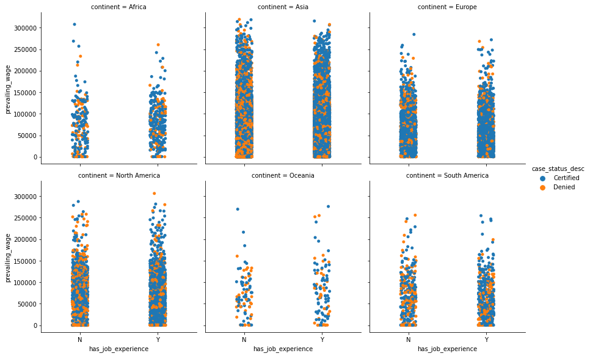

```python
# Categorical Strip plot with a legend - has_job_experience, prevailing_wage, continent and case_status.
sns.catplot(x="has_job_experience",
            y="prevailing_wage",
            hue="case_status_desc",
            col="continent",
            data=Visa_Data,
            kind="strip",
            col_wrap=3,
            height=4
           )
plt.show()
```

#### Observations:

- It can be noticed that the number of denied cases is higher for employees with has_job_experience = 'N'.
- The number of applicants are lower from Oceania, Africa and South America regions, the number of applicants are higher for continent Asia.
- For the continent Europe, the percentage of approvals and rejections for employees with and without job expereince is almost the same.
- Also notice that the prevailing wage is high for visa applications from Asia and North America.

## **3. Questions on Exploratory Data Analysis(EDA)**

### Leading Questions

#### 1. Those with higher education may want to travel abroad for a well-paid job. Does education play a role in Visa certification?

```python
# Grouping the data by "education_of_employee", aggregating for sum and count of records and renaming columns.
Visa_Data_by_Edu = Visa_Data.groupby(by=['education_of_employee']
                                ).agg(
                                    {'case_status_desc':'count', 'case_status': 'sum'}
                                ).reset_index(
                                ).rename(
                                    columns={'case_status':'no_of_cases_denied','case_status_desc':'total_no_of_cases'}
                                )
# Get the number of cases certified
Visa_Data_by_Edu['no_of_cases_certified'] = Visa_Data_by_Edu['total_no_of_cases'] - Visa_Data_by_Edu['no_of_cases_denied']

# Get the percentage of cases certified and denied
Visa_Data_by_Edu['%_of_cases_denied'] = Visa_Data_by_Edu['no_of_cases_denied']/Visa_Data_by_Edu['total_no_of_cases']
Visa_Data_by_Edu['%_of_cases_certified'] = Visa_Data_by_Edu['no_of_cases_certified']/Visa_Data_by_Edu['total_no_of_cases']
Visa_Data_by_Edu
```

|  | education_of_employee | total_no_of_cases | no_of_cases_denied | no_of_cases_certified | %_of_cases_denied | %_of_cases_certified |
| --- | --- | --- | --- | --- | --- | --- |
| 0 | Bachelor's | 10234 | 3867 | 6367 | 0.377858 | 0.622142 |
| 1 | Doctorate | 2192 | 280 | 1912 | 0.127737 | 0.872263 |
| 2 | High School | 3420 | 2256 | 1164 | 0.659649 | 0.340351 |
| 3 | Master's | 9634 | 2059 | 7575 | 0.213722 | 0.786278 |

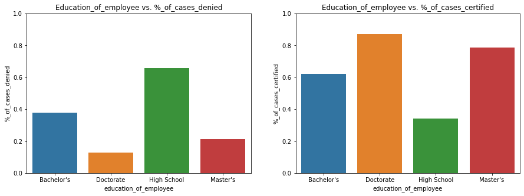

```python
# Set the figure size for the plot
plt.figure(figsize=(15, 5))

# Bar plot for analyzing the fields - Continent and % of cases denied.
plt.subplot(1, 2, 1)
sns.barplot(data=Visa_Data_by_Edu, y="%_of_cases_denied", x="education_of_employee")
# Set the title and y axis scale of the subplot
plt.title('Education_of_employee vs. %_of_cases_denied')
plt.ylim(0, 1)

# Bar plot for analyzing the fields - Continent and % of cases denied.
plt.subplot(1, 2, 2)
sns.barplot(data=Visa_Data_by_Edu, y="%_of_cases_certified", x="education_of_employee")
# Set the title and y axis scale of the subplot
plt.title('Education_of_employee vs. %_of_cases_certified')
plt.ylim(0, 1)

plt.show()
```

#### 2. How does the visa status vary across different continents?

```python
# Grouping the data by "continent", aggregating for sum and count of records and renaming columns.
Visa_Data_by_Continent = Visa_Data.groupby(by=['continent']
                                ).agg(
                                    {'case_status_desc':'count', 'case_status': 'sum'}
                                ).reset_index(
                                ).rename(
                                    columns={'case_status':'no_of_cases_denied','case_status_desc':'total_no_of_cases'}
                                )
# Get the number of cases that are certified.
Visa_Data_by_Continent['no_of_cases_certified'] = Visa_Data_by_Continent['total_no_of_cases'] - Visa_Data_by_Continent['no_of_cases_denied']

# Get the percentage of cases that are certified and denied.
Visa_Data_by_Continent['%_of_cases_denied'] = Visa_Data_by_Continent['no_of_cases_denied']/Visa_Data_by_Continent['total_no_of_cases']
Visa_Data_by_Continent['%_of_cases_certified'] = Visa_Data_by_Continent['no_of_cases_certified']/Visa_Data_by_Continent['total_no_of_cases']
Visa_Data_by_Continent
```

|  | continent | total_no_of_cases | no_of_cases_denied | no_of_cases_certified | %_of_cases_denied | %_of_cases_certified |
| --- | --- | --- | --- | --- | --- | --- |
| 0 | Africa | 551 | 154 | 397 | 0.279492 | 0.720508 |
| 1 | Asia | 16861 | 5849 | 11012 | 0.346895 | 0.653105 |
| 2 | Europe | 3732 | 775 | 2957 | 0.207663 | 0.792337 |
| 3 | North America | 3292 | 1255 | 2037 | 0.381227 | 0.618773 |
| 4 | Oceania | 192 | 70 | 122 | 0.364583 | 0.635417 |
| 5 | South America | 852 | 359 | 493 | 0.421362 | 0.578638 |

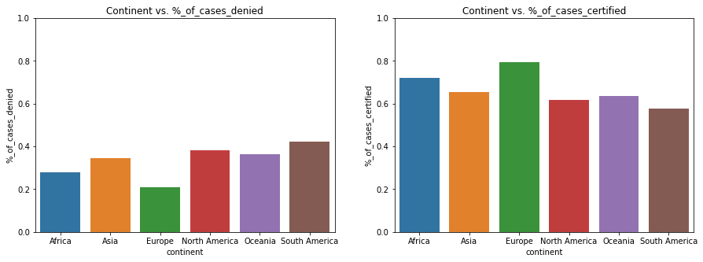

```python
# Set the figure size for the plot
plt.figure(figsize=(15, 5))

# Bar plot for analyzing the fields - Continent and % of cases denied.
plt.subplot(1, 2, 1)
sns.barplot(data=Visa_Data_by_Continent, y="%_of_cases_denied", x="continent")
# Set the title and y axis scale of the subplot
plt.title('Continent vs. %_of_cases_denied')
plt.ylim(0, 1)

# Bar plot for analyzing the fields - Continent and % of cases denied.
plt.subplot(1, 2, 2)
sns.barplot(data=Visa_Data_by_Continent, y="%_of_cases_certified", x="continent")
# Set the title and y axis scale of the subplot
plt.title('Continent vs. %_of_cases_certified')
plt.ylim(0, 1)

plt.show()
```

#### Observations:

- The Visa approval rates are above 60% for all continents except South America which is 58%.
- The Visa approval rates are high for Europe with 79%.
- The approval rates are high for Africa (72%) and Oceania, but the number of applicants are significanly low from these continents.

#### 3. Experienced professionals might look abroad for opportunities to improve their lifestyles and career development. Does work experience influence visa status?

```python
# Grouping the data by "has_job_experience", aggregating for sum and count of records and renaming columns.
Visa_Data_by_Exp = Visa_Data.groupby(by=['has_job_experience']
                                ).agg(
                                    {'case_status_desc':'count', 'case_status': 'sum'}
                                ).reset_index(
                                ).rename(
                                    columns={'case_status':'no_of_cases_denied','case_status_desc':'total_no_of_cases'}
                                )
# Get the number of cases that are certified.
Visa_Data_by_Exp['no_of_cases_certified'] = Visa_Data_by_Exp['total_no_of_cases'] - Visa_Data_by_Exp['no_of_cases_denied']

# Get the percentage of cases that are certified and denied.
Visa_Data_by_Exp['%_of_cases_denied'] = Visa_Data_by_Exp['no_of_cases_denied']/Visa_Data_by_Exp['total_no_of_cases']
Visa_Data_by_Exp['%_of_cases_certified'] = Visa_Data_by_Exp['no_of_cases_certified']/Visa_Data_by_Exp['total_no_of_cases']
Visa_Data_by_Exp
```

|  | has_job_experience | total_no_of_cases | no_of_cases_denied | no_of_cases_certified | %_of_cases_denied | %_of_cases_certified |
| --- | --- | --- | --- | --- | --- | --- |
| 0 | N | 10678 | 4684 | 5994 | 0.438659 | 0.561341 |
| 1 | Y | 14802 | 3778 | 11024 | 0.255236 | 0.744764 |

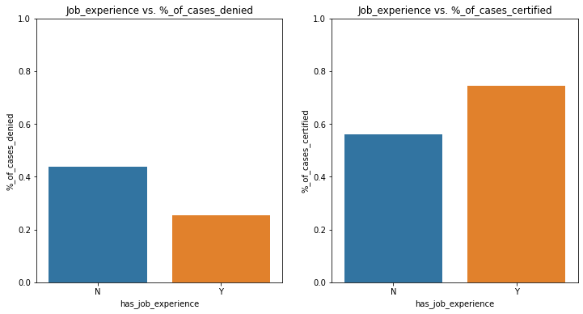

```python
# Set the figure size for the plot
plt.figure(figsize=(12, 6))

# Bar plot for analyzing the fields - has_job_experience and % of cases denied.
plt.subplot(1, 2, 1)
sns.barplot(data=Visa_Data_by_Exp, y="%_of_cases_denied", x="has_job_experience")
# Set the title and y axis scale of the subplot
plt.title('Job_experience vs. %_of_cases_denied')
plt.ylim(0, 1)

# Bar plot for analyzing the fields - has_job_experience and % of cases denied.
plt.subplot(1, 2, 2)
sns.barplot(data=Visa_Data_by_Exp, y="%_of_cases_certified", x="has_job_experience")
# Set the title and y axis scale of the subplot
plt.title('Job_experience vs. %_of_cases_certified')
plt.ylim(0, 1)

plt.show()
```

#### Observations:

- Yes, work experience does influence the visa status.
- For the observations with has_job_experience = 'Y', the visa approval rates is 74%
- For the observations with has_job_experience = 'N', the visa approval rates is only 56%

#### 4. In the United States, employees are paid at different intervals. Which pay unit is most likely to be certified for a visa?

```python
# Grouping the data by "has_job_experience", aggregating for sum and count of records and renaming columns.
Visa_Data_by_PayUnit = Visa_Data.groupby(by=['unit_of_wage']
                                ).agg(
                                    {'case_status_desc':'count', 'case_status': 'sum'}
                                ).reset_index(
                                ).rename(
                                    columns={'case_status':'no_of_cases_denied','case_status_desc':'total_no_of_cases'}
                                )
# Get the number of cases that are certified.
Visa_Data_by_PayUnit['no_of_cases_certified'] = Visa_Data_by_PayUnit['total_no_of_cases'] - Visa_Data_by_PayUnit['no_of_cases_denied']

# Get the percentage of cases that are certified and denied.
Visa_Data_by_PayUnit['%_of_cases_denied'] = Visa_Data_by_PayUnit['no_of_cases_denied']/Visa_Data_by_PayUnit['total_no_of_cases']
Visa_Data_by_PayUnit['%_of_cases_certified'] = Visa_Data_by_PayUnit['no_of_cases_certified']/Visa_Data_by_PayUnit['total_no_of_cases']
Visa_Data_by_PayUnit
```

|  | unit_of_wage | total_no_of_cases | no_of_cases_denied | no_of_cases_certified | %_of_cases_denied | %_of_cases_certified |
| --- | --- | --- | --- | --- | --- | --- |
| 0 | Hour | 2157 | 1410 | 747 | 0.653686 | 0.346314 |
| 1 | Month | 89 | 34 | 55 | 0.382022 | 0.617978 |
| 2 | Week | 272 | 103 | 169 | 0.378676 | 0.621324 |
| 3 | Year | 22962 | 6915 | 16047 | 0.301150 | 0.698850 |

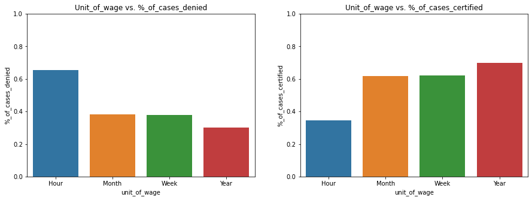

```python
# Set the figure size for the plot
plt.figure(figsize=(15, 5))

# Bar plot for analyzing the fields - Unit_of_wage and % of cases denied.
plt.subplot(1, 2, 1)
sns.barplot(data=Visa_Data_by_PayUnit, y="%_of_cases_denied", x="unit_of_wage")
# Set the title and y axis scale of the subplot
plt.title('Unit_of_wage vs. %_of_cases_denied')
plt.ylim(0, 1)

# Bar plot for analyzing the fields - Unit_of_wage and % of cases denied.
plt.subplot(1, 2, 2)
sns.barplot(data=Visa_Data_by_PayUnit, y="%_of_cases_certified", x="unit_of_wage")
# Set the title and y axis scale of the subplot
plt.title('Unit_of_wage vs. %_of_cases_certified')
plt.ylim(0, 1)

plt.show()
```

#### 5. The US government has established a prevailing wage to protect local talent and foreign workers. How does the visa status change with the prevailing wage?

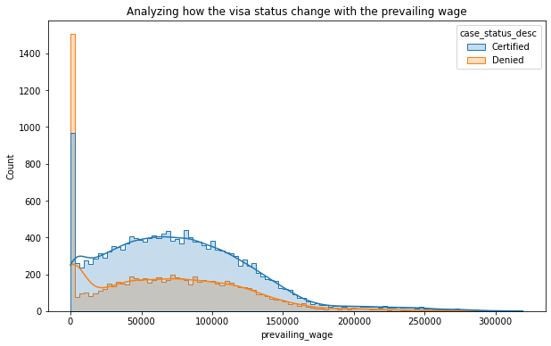

```python
# Set the figure size and title for the plot
plt.figure(figsize=(10, 6))
plt.title('Analyzing how the visa status change with the prevailing wage')

# Hist plot for analyzing the field prevailing_wage and case_status
sns.histplot(data=Visa_Data,x='prevailing_wage',hue='case_status_desc',element='step',bins=100,kde=True)

plt.show()
```

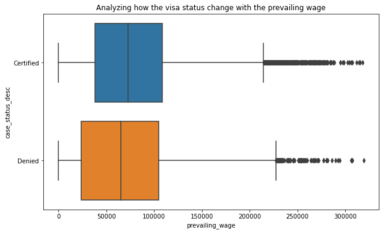

```python
# Set the figure size and title for the plot
plt.figure(figsize=(10, 6))
plt.title('Analyzing how the visa status change with the prevailing wage')

# Box plot for analyzing the field prevailing_wage and case_status
sns.boxplot(data=Visa_Data,x='prevailing_wage',y='case_status_desc')

plt.show()
```

#### Observations:

- It can be noticed that the median prevailing wage for approval cases is marginally higher than median prevailing wage for denied cases.
- There are so many observatios with extremly high prevailing wages, that can be conisderd as outliers.
- The observations could be biased becasue the number of observations for visa certfied cases is higher than the number of observations with visa denied cases.

## Data Preprocessing (continued...)

### Feature engineering

Creating a new column 'has_job*exp*&_no_training_req' based on columns 'has_job_experience' and 'requires_job_training'.

```python
# This will help to see if employees with job experience and requires no training has an advantage.
# This idea is suggested by my mentor Yogesh Singh.

Visa_Data['has_job_exp_&_no_training_req'] = (
    Visa_Data['has_job_experience'].astype('str') + Visa_Data['requires_job_training'].astype('str')
).apply(lambda x:1 if x == "YN" else 0)
```

```python
# Get a sample 10 rows of data using random state = 1
Visa_Data.sample(n=10, random_state=1)
```

|  | continent | education_of_employee | has_job_experience | requires_job_training | no_of_employees | yr_of_estab | region_of_employment | prevailing_wage | unit_of_wage | full_time_position | case_status_desc | case_status | has_job_exp_&_no_training_req |
| --- | --- | --- | --- | --- | --- | --- | --- | --- | --- | --- | --- | --- | --- |
| 17639 | Asia | Bachelor's | Y | N | 567 | 1992 | Midwest | 26842.9100 | Year | Y | Certified | 0 | 1 |
| 23951 | Oceania | Bachelor's | N | N | 619 | 1938 | Midwest | 66419.9800 | Year | Y | Certified | 0 | 0 |
| 8625 | Asia | Master's | N | N | 2635 | 2005 | South | 887.2921 | Hour | Y | Certified | 0 | 0 |
| 20206 | Asia | Bachelor's | Y | Y | 3184 | 1986 | Northeast | 49435.8000 | Year | Y | Certified | 0 | 0 |
| 7471 | Europe | Bachelor's | Y | N | 4681 | 1928 | West | 49865.1900 | Year | Y | Denied | 1 | 1 |
| 3433 | Asia | Bachelor's | Y | N | 222 | 1989 | South | 813.7261 | Hour | Y | Certified | 0 | 1 |
| 24440 | Europe | High School | N | Y | 3278 | 1994 | South | 204948.3900 | Year | Y | Denied | 1 | 0 |
| 12104 | Asia | Master's | Y | N | 1359 | 1997 | West | 202237.0400 | Year | N | Certified | 0 | 1 |
| 15656 | Asia | Bachelor's | N | N | 2081 | 2003 | West | 111713.0200 | Year | Y | Denied | 1 | 0 |
| 23110 | North America | Bachelor's | Y | N | 854 | 1998 | Northeast | 444.8257 | Hour | Y | Denied | 1 | 1 |

### A closer look at 'Prevailing Wage'and 'Unit of Wage' columns

```python
# Group the data by 'unit of wage' and get the median, mean, minimum and maximum.
Visa_Data_by_Unit_Wage = Visa_Data.groupby(by=['unit_of_wage']
                                          ).agg({'prevailing_wage':['mean','median','min','max']}
                                               ).reset_index()
Visa_Data_by_Unit_Wage
```

|  | unit_of_wage | prevailing_wage mean | prevailing_wage median | prevailing_wage min | prevailing_wage max |
| --- | --- | --- | --- | --- | --- |
| 0 | Hour | 414.570513 | 372.6523 | 2.1367 | 999.9195 |
| 1 | Month | 87592.864045 | 81826.0100 | 1599.2800 | 264362.9500 |
| 2 | Week | 85606.820515 | 85075.8200 | 2183.2300 | 280175.9500 |
| 3 | Year | 81228.077133 | 76174.5000 | 100.0000 | 319210.2700 |

#### Observations:

1. I was initially under the impression that we have multiply the wage for Hour, Week and Month units to make it equivalent to Year unit.
2. But after looking at the mean and median prevailing wages of Month and Week, it was found that the amount is inline with Year unit.
3. The mean and median prevailing wage of Hour is much low. Assuming these are hourly jobs and the wage is low for these jobs, I have decided to leave the 'prevailing_wage' field as it is.

### Column Encoding

Let's encode the categorical columns - 'continent', 'education_of_employee', 'has_job_experience', 'requires_job_training', 'region_of_employment', 'unit_of_wage', 'full_time_position'

- For the column 'education_of_employee', let's replace the column with numerical value that makes sense.
- For the remaining columns, perform onehot encoding on that column.

```python
# Display the values in the column - education_of_employee
print(Visa_Data['education_of_employee'].value_counts())
```

```
Bachelor's     10234
Master's        9634
High School     3420
Doctorate       2192
Name: education_of_employee, dtype: int64
```

```python
# Create a structure to encode the column values - type_of_meal_plan and room_type_reserved
ValueReplaceStruct = {
    "education_of_employee":{"High School":0,"Bachelor's":1,"Master's":2,"Doctorate":3}
}
```

```python
# Display the replace struct
ValueReplaceStruct
```

```
{'education_of_employee': {'High School': 0,
  "Bachelor's": 1,
  "Master's": 2,
  'Doctorate': 3}}
```

```python
# Encode the column values - education_of_employee
Visa_Data.replace(ValueReplaceStruct,inplace=True)
```

```python
# Assign remaining columns to the list oneHotCols
oneHotCols=['continent',
            'has_job_experience',
            'requires_job_training',
            'region_of_employment',
            'unit_of_wage',
            'full_time_position'
           ]
```

```python
# OneHot encode columns 'continent','has_job_experience','requires_job_training','region_of_employment','unit_of_wage','full_time_position'
Visa_Data=pd.get_dummies(Visa_Data, columns=oneHotCols, drop_first=True)
```

```python
# Get a sample 10 rows of data using random state = 1
Visa_Data.sample(n=10, random_state=1)
```

|  | education_of_employee | no_of_employees | yr_of_estab | prevailing_wage | case_status_desc | case_status | has_job_exp_&_no_training_req | continent_Asia | continent_Europe | continent_North America | continent_Oceania | continent_South America | has_job_experience_Y | requires_job_training_Y | region_of_employment_Midwest | region_of_employment_Northeast | region_of_employment_South | region_of_employment_West | unit_of_wage_Month | unit_of_wage_Week | unit_of_wage_Year | full_time_position_Y |
| --- | --- | --- | --- | --- | --- | --- | --- | --- | --- | --- | --- | --- | --- | --- | --- | --- | --- | --- | --- | --- | --- | --- |
| 17639 | 1 | 567 | 1992 | 26842.9100 | Certified | 0 | 1 | 1 | 0 | 0 | 0 | 0 | 1 | 0 | 1 | 0 | 0 | 0 | 0 | 0 | 1 | 1 |
| 23951 | 1 | 619 | 1938 | 66419.9800 | Certified | 0 | 0 | 0 | 0 | 0 | 1 | 0 | 0 | 0 | 1 | 0 | 0 | 0 | 0 | 0 | 1 | 1 |
| 8625 | 2 | 2635 | 2005 | 887.2921 | Certified | 0 | 0 | 1 | 0 | 0 | 0 | 0 | 0 | 0 | 0 | 0 | 1 | 0 | 0 | 0 | 0 | 1 |
| 20206 | 1 | 3184 | 1986 | 49435.8000 | Certified | 0 | 0 | 1 | 0 | 0 | 0 | 0 | 1 | 1 | 0 | 1 | 0 | 0 | 0 | 0 | 1 | 1 |
| 7471 | 1 | 4681 | 1928 | 49865.1900 | Denied | 1 | 1 | 0 | 1 | 0 | 0 | 0 | 1 | 0 | 0 | 0 | 0 | 1 | 0 | 0 | 1 | 1 |
| 3433 | 1 | 222 | 1989 | 813.7261 | Certified | 0 | 1 | 1 | 0 | 0 | 0 | 0 | 1 | 0 | 0 | 0 | 1 | 0 | 0 | 0 | 0 | 1 |
| 24440 | 0 | 3278 | 1994 | 204948.3900 | Denied | 1 | 0 | 0 | 1 | 0 | 0 | 0 | 0 | 1 | 0 | 0 | 1 | 0 | 0 | 0 | 1 | 1 |
| 12104 | 2 | 1359 | 1997 | 202237.0400 | Certified | 0 | 1 | 1 | 0 | 0 | 0 | 0 | 1 | 0 | 0 | 0 | 0 | 1 | 0 | 0 | 1 | 0 |
| 15656 | 1 | 2081 | 2003 | 111713.0200 | Denied | 1 | 0 | 1 | 0 | 0 | 0 | 0 | 0 | 0 | 0 | 0 | 0 | 1 | 0 | 0 | 1 | 1 |
| 23110 | 1 | 854 | 1998 | 444.8257 | Denied | 1 | 1 | 0 | 0 | 1 | 0 | 0 | 1 | 0 | 0 | 1 | 0 | 0 | 0 | 0 | 0 | 1 |

### Outlier detection and treatment

For now, I have decided not to do outlier treatment as the models are capable of handling outliers.

### Preparing data for modeling

#### Splitting up Data for Model Prediction

```python
# defining X and y variables
X = Visa_Data.drop(['case_status','case_status_desc'],axis=1)
y = Visa_Data['case_status']
```

```python
# Get a copy of X and y varaibles for use in later models
X_copy = X.copy()
y_copy = y.copy()
```

```python
# Library to split data
from sklearn.model_selection import train_test_split

# splitting the data in 70:30 ratio for train to test data
X_train, X_test, y_train, y_test = train_test_split(
    X, y, test_size=0.3, random_state=1, stratify=y
)

print("Number of rows in train data =", X_train.shape[0])
print("Number of rows in test data =", X_test.shape[0])
```

```
Number of rows in train data = 17836
Number of rows in test data = 7644
```

```python
print("Original Denied Cases       : {0} ({1:0.2f}%)".format(len(Visa_Data.loc[Visa_Data['case_status'] == 1]), (len(Visa_Data.loc[Visa_Data['case_status'] == 1])/len(Visa_Data.index)) * 100))
print("Original Certified Cases    : {0} ({1:0.2f}%)".format(len(Visa_Data.loc[Visa_Data['case_status'] == 0]), (len(Visa_Data.loc[Visa_Data['case_status'] == 0])/len(Visa_Data.index)) * 100))
print("")
print("Training Denied Cases       : {0} ({1:0.2f}%)".format(len(y_train[y_train[:] == 1]), (len(y_train[y_train[:] == 1])/len(y_train)) * 100))
print("Training Certified Cases    : {0} ({1:0.2f}%)".format(len(y_train[y_train[:] == 0]), (len(y_train[y_train[:] == 0])/len(y_train)) * 100))
print("")
print("Test Denied Cases           : {0} ({1:0.2f}%)".format(len(y_test[y_test[:] == 1]), (len(y_test[y_test[:] == 1])/len(y_test)) * 100))
print("Test Certified Cases        : {0} ({1:0.2f}%)".format(len(y_test[y_test[:] == 0]), (len(y_test[y_test[:] == 0])/len(y_test)) * 100))
```

```
Original Denied Cases       : 8462 (33.21%)
Original Certified Cases    : 17018 (66.79%)

Training Denied Cases       : 5923 (33.21%)
Training Certified Cases    : 11913 (66.79%)

Test Denied Cases           : 2539 (33.22%)
Test Certified Cases        : 5105 (66.78%)
```

There are 33.21% of visa denied cases in original dataset. This ratio is consistent with Training and testing dataset.

### Model evaluation criterion

#### The model can make wrong predictions as:

- Predicting a visa applicant will have the visa certified when the applicant gets visa denied.
- Predicting a visa applicant will have visa denied when the applicant gets visa certified.

#### Which case is more important?

A Works visa in United States is applied in March and the results are expected in August. So if an emplpyee gets visa denied, then he/she should wait for an year to repplying again. This one in a year chance is more painful than the money spend in applying for it.

- If the model predicts a visa applicant will have the visa certified when the applicant gets it denied, then EasyVisa would incur the loss of resources used in applying for visa. The applicant will loose an year trying to fix the issues and reapply again next year.
- If the model predicts a visa applicant will have visa denied when the applicant gets visa certified then EasyVisa would loose chance of a successful certifcation. But we can assume that as the next step EasyVisa will carefully review the application, improve the important feartures and still apply for the visa and get it certified.

#### Which metric to optimize?

- This Machine learning model will be used an a first step to identify if an application has a chance of rejection or not. We would want recall to be maximized, the greater the recall means that the model will find every applicant for whom there is a minor chance of rejection.
- For every applicant whom the machine learning model identifes for visa denial, EasyVisa should review the application throughly, improve the important feartures and apply for visa.

### Functions for calculating Model Performance

First, let's create functions to calculate different metrics and confusion matrix so that we don't have to use the same code repeatedly for each model.

- The model_performance_classification_sklearn function will be used to check the model performance of models.
- The confusion_matrix_sklearn function will be used to plot confusion matrix

```python
# defining a function to compute different metrics to check performance of a classification model built using sklearn
def model_performance_classification_sklearn(model, predictors, target):
    """
    Function to compute different metrics to check classification model performance

    model: classifier
    predictors: independent variables
    target: dependent variable
    """

    # predicting using the independent variables
    pred = model.predict(predictors)

    acc = accuracy_score(target, pred)  # to compute Accuracy
    recall = recall_score(target, pred)  # to compute Recall
    precision = precision_score(target, pred)  # to compute Precision
    f1 = f1_score(target, pred)  # to compute F1-score

    # creating a dataframe of metrics
    df_perf = pd.DataFrame(
        {
            "Accuracy": acc,
            "Recall": recall,
            "Precision": precision,
            "F1": f1,
        },
        index=[0],
    )

    return df_perf
```

```python
def confusion_matrix_sklearn(model, predictors, target):
    """
    To plot the confusion_matrix with percentages

    model: classifier
    predictors: independent variables
    target: dependent variable
    """
    y_pred = model.predict(predictors)
    cm = confusion_matrix(target, y_pred)
    labels = np.asarray(
        [
            ["{0:0.0f}".format(item) + "\n{0:.2%}".format(item / cm.flatten().sum())]
            for item in cm.flatten()
        ]
    ).reshape(2, 2)

    plt.figure(figsize=(6, 4))
    sns.heatmap(cm, annot=labels, fmt="")
    plt.ylabel("True label")
    plt.xlabel("Predicted label")
```